# $SPY Twitter Sentiment Analysis

Juan Zambrano & Xiomara Chirinos

12/6/2020

## Abstract

Our group of Data Scientists scholars has the objective of evaluating Twitter’s user’s sentiment on the stock market by obtaining tweets about the S & P 500 index and its derivatives. The S & P 500 represents the biggest 500 publicly traded companies in the United States making up a great portion of the stock market with a total of 15 trillion in market cap. We will be utilizing financial terms both formal and informal to capture users’ sentiments on the index.

The steps to obtain relatable data will be to utilize an API from Twitter that would allow us to withdraw specific tweets from its servers. We will be obtaining tweets utilizing a familiar symbol in Fintwit (Financial Twitter) such as $ (Dollar Sign). The dollar sign is used to represent financial instruments such as the S & P 500 (Ex. $SPY). Because our goal is to capture sentiment, we will be using other financial terms such as “bullish”, “bearish”, “long”, “short”, “options call”, “options put”, among other terms to identify the user’s sentiment on the S & P 500.

We consider our project of big relevance to the public due to the importance the United States stock market has in the economy of the US and the world. Additionally, the stock market is currently at an interesting place where it has recently reached all-time highs. Could twitter determine if the market will continue its bullish trend? Will it predict the start of a bear market? We hope that with our project’s outcome we can collect actionable information to be used by traders.

# Table of contents

### 1. Data Import

#### Twitter Connection

```r
# store api keys
api_key_x <- "MOqJTxSWIltmfdykwZTP3pOzo"
api_secret_key_x <- "BLhc8W1YVE68TRd0TeSvUl5QzbchFMMpmI0egcAnGDM3amEATd"
access_token_x <- "1326315578458562564-bxP5bd84pyJdph3HT8YxQP405jot4B"
access_token_secret_x <- "SANAoJb3kPZkMqfhRbw2Euj4QCK7GjXQQEWdM29FLY2dc"

# authenticate via web browser
token_x <- create_token(
  app = "XiomaraChirnos_TextAnalysis",
  consumer_key = api_key_x,
  consumer_secret = api_secret_key_x,
  access_token = access_token_x,
  access_secret = access_token_secret_x)
```

#### Tweets Search

```r
#SPY_Tweets_X <- search_tweets("$SPY", n = 18000, include_rts = FALSE)
```

### 2. Export to AWS

#### Exporting our Data Sets into an Amazon Web Services

```r
# Instance Details
host = "xchirinos-database.ciowvfrrrqse.us-east-1.rds.amazonaws.com"
port = 3306
user = "admin"
dbname = "xchirinosdatabase"
password = "potamita5181305"

# Connecting to Database
con = DBI::dbConnect(
  RMySQL::MySQL(),
  dbname = dbname,
  host = host,
  port = port,
  user = user,
  password = password
)
```

```r
# Creating a New Table
# dbCreateTable(conn = con, name = "SPY_TWEETS", fields = SPY_Final_XJ, row.names = NULL)
```

```r
# Writing data frame to table
# dbWriteTable(
#   conn = con,
#   name = "SPY_TWEETS",
#   value = SPY_Final_XJ,
#   append = TRUE,
#   row.names = FALSE
#  )
```

```r
# Reading Tables
dbReadTable(con, "SPY_TWEETS")
```

### 3. Data Transformation

#### Importing and Combining Group’s Datasets

```r
# combining all groups of datasets
# SPY_Final_Data_X <- rbind(SPY_Tweets_X, SPY_Tweets_X1, SPY_Tweets_X2, SPY_Tweets_X3, SPY_Tweets_X4, SPY_Tweets_X5, SPY_Tweets_X6, SPY_Tweets_X7, SPY_Tweets_X8, SPY_Tweets_X9)

# combining Juan and Xiomara datasets
# SPY_Final_Data_XJ <- rbind(SPY_Final_Data_J, SPY_Final_Data_X)

# exporting data as csv
# write_as_csv(SPY_Final_Data_XJ, "SPY_Final_Data_Xj", prepend_ids = TRUE, na = "", fileEncoding = "UTF-8")

# save_as_csv(SPY_Final_Data_Xj, "SPY_Final_Data_Xj", prepend_ids = TRUE, na = "", fileEncoding = "UTF-8")

# SPY_Final_Data_XJ_NODUP <-  SPY_Final_Data_XJ[!duplicated(SPY_Final_Data_XJ[ , c("status_id")]),]
```

#### Selecting the Variables of Value for the project

```r
SPY_Final_XJ_2 <- read.csv("SPY_Final_Data_XJ_NODUP.csv")

SPY_Final_XJ <- SPY_Final_XJ_2 %>% separate(created_at, into = c("Date", "Time"), sep = " ", convert = TRUE)

SPY_Final_XJ$Time <- as.hms(SPY_Final_XJ$Time)
SPY_Final_XJ$Date <- as.Date(SPY_Final_XJ$Date)

SPY_Final_XJ <- SPY_Final_XJ %>% select(user_id, status_id, Date, Time, screen_name, text, source, display_text_width, reply_to_status_id, is_quote, favorite_count, retweet_count, hashtags, symbols, lang, name, location, description, protected, followers_count, friends_count, listed_count, statuses_count, favourites_count, account_created_at, verified, reply_to_status_id)

# create a copy of the dataset for each model
SPY_Sentiment <- SPY_Final_XJ
SPY_LG <- SPY_Final_XJ
SPY_TREE <- SPY_Final_XJ
SPY_CART <- SPY_Final_XJ
SPY_NB <- SPY_Final_XJ
SPY_TS <- SPY_Final_XJ
```

### 4. Sentiment Analysis

#### Running a word search package to obtain general sentiment of our Tweets

We utilized packages “tidytext” and “afinn” to get an idea of the general sentiment of Tweets while using common words used in our day to day lives. The “afinn” lexicon is a list of positive and negative polar words with some score associated with them, and we will be using it to qualify the sentiment as positive or negative.

```r
# convert the data set to a text corpus
tweet_corp <- quanteda::corpus(SPY_Sentiment,
text="text")

# quick summary
summary(tweet_corp,
n=2)
```

```
## Corpus consisting of 29869 documents, showing 2 documents:
##
##   Text Types Tokens Sentences    user_id             status_id       Date
##  text1    28     32         1 xx79233326 xx1335245313532178432 2020-12-05
##  text2    39     51         2 xx79233326 xx1334884082786988040 2020-12-04
##      Time     screen_name         source display_text_width reply_to_status_id
##  15:31:05 ElliottForecast StockTwits Web                163
##  15:35:40 ElliottForecast StockTwits Web                243
##  is_quote favorite_count retweet_count            hashtags      symbols lang
##     FALSE              0             0 elliottwave trading CL_F SPX SPY   en
##     FALSE              0             0                              SPY   en
##                  name     location
##  Elliottwave Forecast Miami/London
##  Elliottwave Forecast Miami/London
##                                                                                                                                                               description
##  Elliott Wave Forecasts of 78 markets. Webinars, Chat Room, Trade Setups & more. Ideas purely Educational, not recommendations. Free 14 Day Trial https://t.co/irXLw1z0Sq
##  Elliott Wave Forecasts of 78 markets. Webinars, Chat Room, Trade Setups & more. Ideas purely Educational, not recommendations. Free 14 Day Trial https://t.co/irXLw1z0Sq
##  protected followers_count friends_count listed_count statuses_count
##      FALSE           23365            18          617         373970
##      FALSE           23365            18          617         373970
##  favourites_count  account_created_at verified
##                42 2009-10-02 17:18:19    FALSE
##                42 2009-10-02 17:18:19    FALSE
```

```r
senti <- get_sentiments("afinn")
head(senti)
```

```
## # A tibble: 6 x 2
##   word       value
##   <chr>      <dbl>
## 1 abandon       -2
## 2 abandoned     -2
## 3 abandons      -2
## 4 abducted      -2
## 5 abduction     -2
## 6 abductions    -2
```

```r
# Reading our tweets in again and merge the sentiments
tweet_tidy <- as_tibble(SPY_Sentiment) %>%
# tokenize the tweets
tidytext::unnest_tokens(word, text) %>%
# merge sentiment
inner_join(senti)
# now we can group the sentiment by tweets and a positivity score by totaling the sentiments

positivity <- tweet_tidy %>%
group_by(status_id) %>%
summarise(positiv=sum(value))
head(positivity)
```

```
## # A tibble: 6 x 2
##   status_id             positiv
##   <chr>                   <dbl>
## 1 xx1329798239466315776       4
## 2 xx1329798443087372289       1
## 3 xx1329798482555793416       2
## 4 xx1329798516093358080      -1
## 5 xx1329798894612475905       2
## 6 xx1329799104931749891       2
```

```r
#  plot the score
tweet_tidy <- as_tibble(SPY_Sentiment) %>%
inner_join(positivity, by="status_id")
```

#### Visualizations

##### 1

A graph was created to determine the average sentiment trend vs the days where we collected Tweets.

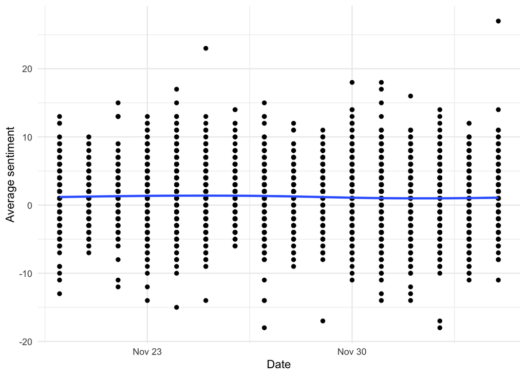

```r
# sentiment visualization
ggplot(tweet_tidy, aes(x=Date, y=positiv)) +
geom_point() +
geom_smooth() +
theme_minimal() +
labs(x="Date",
y="Average sentiment")
```

##### 2

In this graph we can see the different sentiments vs scores. We can see that negative and positive have the biggest score with positive taking the lead.

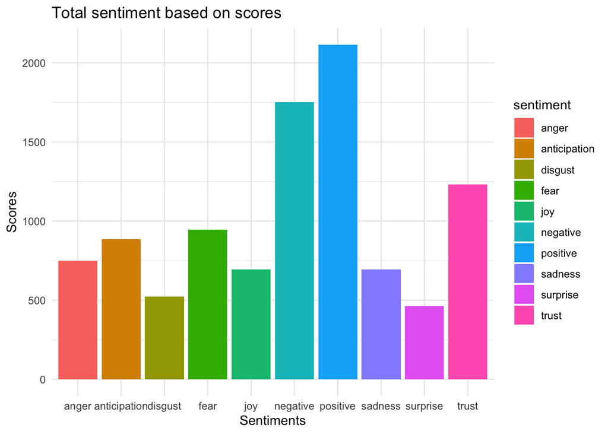

```r
# Converting tweets to ASCII to trackle strange characters
tweets2 <- iconv(SPY_Sentiment, from="UTF-8", to="ASCII", sub="")
# removing retweets, in case needed
tweets2 <-gsub("(RT|via)((?:\\b\\w*@\\w+)+)","",tweets2)
# removing mentions, in case needed
tweets2 <-gsub("@\\w+","",tweets2)
ew_sentiment<-get_nrc_sentiment((tweets2))
sentimentscores<-data.frame(colSums(ew_sentiment[,]))
names(sentimentscores) <- "Score"
sentimentscores <- cbind("sentiment"=rownames(sentimentscores),sentimentscores)
rownames(sentimentscores) <- NULL
ggplot(data=sentimentscores,aes(x=sentiment,y=Score))+
  geom_bar(aes(fill=sentiment),stat = "identity")+
  theme(legend.position="none")+
  xlab("Sentiments")+ylab("Scores")+
  ggtitle("Total sentiment based on scores")+
  theme_minimal()
```

#### Creating our specific keywords dataset to obtain sentiment of our Tweets

We searched specific financial terms both formal and informal that are typically used by traders and/or people involved in Twitter for financial market purposes.

Positive words: Bullish, Bull Market, Long, Call, BTFD and Bottom.

```r
# positive sentiment
Bullish <- sum(str_detect(SPY_Sentiment$text, regex('bullish', ignore_case = TRUE)))
BullMarket <- sum(str_detect(SPY_Sentiment$text, regex('Bull Market', ignore_case = TRUE)))
Long <- sum(str_detect(SPY_Sentiment$text, regex('long', ignore_case = TRUE)))
OptionsCall <- sum(str_detect(SPY_Sentiment$text, regex('Call', ignore_case = TRUE)))
BTFD <- sum(str_detect(SPY_Sentiment$text, regex('BTFD', ignore_case = TRUE)))
Bottom <- sum(str_detect(SPY_Sentiment$text, regex('Bottom', ignore_case = TRUE)))
```

```
## Tweets that mention Bullish: 673
```

```
## Tweets that mention Bull Market: 40
```

```
## Tweets that mention Long: 1197
```

```
## Tweets that mention Options Call: 1425
```

```
## Tweets that mention BTFD: 32
```

```
## Tweets that mention Bottom: 324
```

Negative words: Bearish, Bear Market, Short, Put, STFR and Top

```r
# negative sentiment
Bearish <- sum(str_detect(SPY_Sentiment$text, regex('bearish', ignore_case = TRUE)))
BearMarket <- sum(str_detect(SPY_Sentiment$text, regex('Bear Market', ignore_case = TRUE)))
Short <- sum(str_detect(SPY_Sentiment$text, regex('short', ignore_case = TRUE)))
OptionsPut <- sum(str_detect(SPY_Sentiment$text, regex('Put', ignore_case = TRUE)))
STFR <- sum(str_detect(SPY_Sentiment$text, regex('STFR', ignore_case = TRUE)))
Top <- sum(str_detect(SPY_Sentiment$text, regex('Top', ignore_case = TRUE)))
```

```
## Tweets that mention Bearish: 282
```

```
## Tweets that mention Bear Market: 15
```

```
## Tweets that mention Short: 1193
```

```
## Tweets that mention Options Put: 1191
```

```
## Tweets that mention STFR: 1
```

```
## Tweets that mention Top: 1482
```

```r
# KeyWordsSentiment <- tibble (KeyWord = c("Bullish", "Bearish", "Bull Market", "Bear Market", "Long", "Short", "Call", "Put", "BTFD", "STFD", "Bottom", "Top"),
# Count = c(673, 282, 40, 15, 1197, 1193, 1425, 1191, 32, 1, 324, 1482),
# Sentiment = c("Positive", "Negative", "Positive", "Negative","Positive", "Negative","Positive", "Negative","Positive", "Negative","Positive", "Negative"))

# export sentiment data
# write.csv(KeyWordsSentiment, file = "KeyWordsSentiment.csv")

# import sentiment data as factors
KeyWordsSentiment2 <- read.csv("KeyWordsSentiment.csv", stringsAsFactors = TRUE)
```

#### Visualization

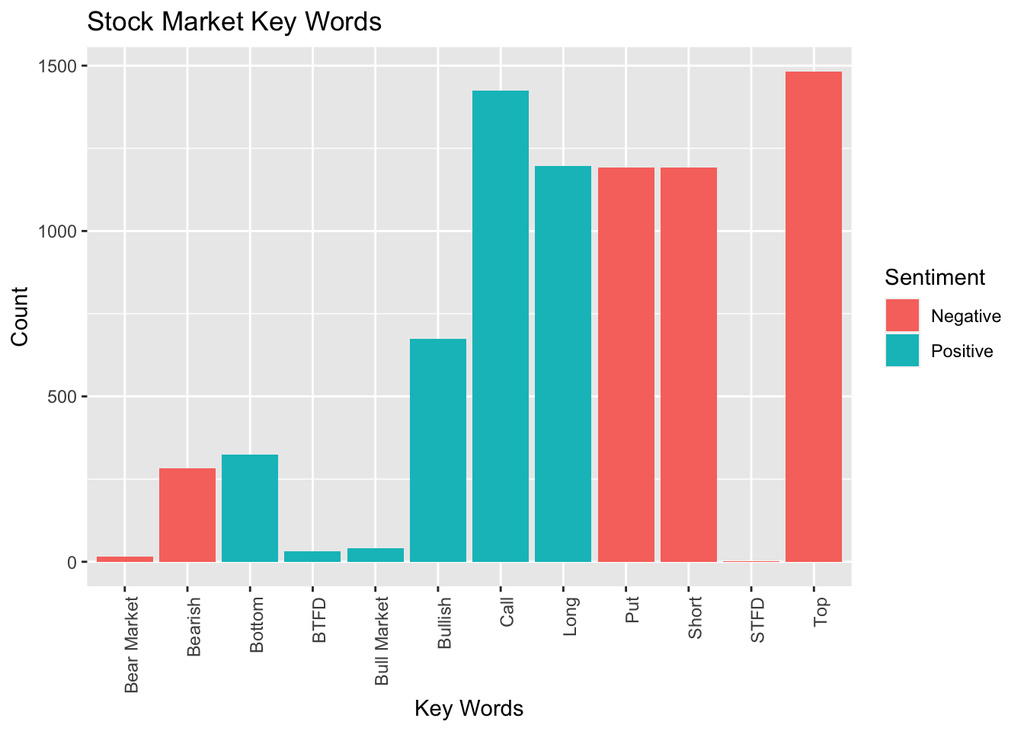

```r
ggplot(data = KeyWordsSentiment2,
       mapping = aes(x = KeyWord, y = Count, fill = Sentiment)) +
  geom_col()+
    theme(axis.text.x = element_text(angle = 90, hjust = 1)) +
  labs(title = "Stock Market Key Words",
       x = "Key Words",
       y = "Count",
       fill = "Sentiment")
```

### 5. Logistic Regression

#### Running Model

We appealed to the Logistic Regression model to be able to predict if our Tweets collected were Organic or No Organic. An organic tweet can be defined as to be wrote and sent by an users at a specific time. On the other hand, a No Organic tweets is wrote in anticipation and sent at a later time by scheduling platform.

We classified tweets coming from ‘Twitter Web App’, ‘Twitter for iPhone’, and ‘Twitter for Android’ to be Organic and others to be otherwise No Organic. We ran the model utilizing numeric value from our data like ‘display_text_width’, ‘followers_count’ and ‘favourites_count’

```r
# data preparation
SPY_LG <- mutate(SPY_LG, Organic = ifelse(source == "Twitter Web App" | source == "Twitter for iPhone" | source == "Twitter for Android", "Organic", "No Organic"))

SPY_LG$Organic <- factor(SPY_LG$Organic, levels=c("Organic", "No Organic"))

# sample data

# Set the random seed for repeatability
set.seed(123)

# Split the data into 3:1 ratio
SPY_LG$Sample_LG <- sample.split(SPY_LG$Organic, SplitRatio = .75)

train_LG <- subset(SPY_LG, Sample_LG == TRUE)
test_LG <- subset(SPY_LG, Sample_LG == FALSE)

# build LG model
LG_Model <- glm(formula = Organic ~ display_text_width + followers_count + favourites_count,
               data = train_LG,
               family = binomial)

summary(LG_Model)
```

```
##
## Call:
## glm(formula = Organic ~ display_text_width + followers_count +
##     favourites_count, family = binomial, data = train_LG)
##
## Deviance Residuals:
##     Min       1Q   Median       3Q      Max
## -2.1039  -0.9062  -0.6849   1.3351   4.3141
##
## Coefficients:
##                      Estimate Std. Error z value Pr(>|z|)
## (Intercept)        -4.476e-02  2.995e-02  -1.494    0.135
## display_text_width -4.845e-03  1.774e-04 -27.313   <2e-16 ***
## followers_count     8.535e-06  8.531e-07  10.005   <2e-16 ***
## favourites_count   -1.905e-05  1.433e-06 -13.292   <2e-16 ***
## ---
## Signif. codes:  0 '***' 0.001 '**' 0.01 '*' 0.05 '.' 0.1 ' ' 1
##
## (Dispersion parameter for binomial family taken to be 1)
##
##     Null deviance: 27686  on 22401  degrees of freedom
## Residual deviance: 26647  on 22398  degrees of freedom
## AIC: 26655
##
## Number of Fisher Scoring iterations: 5
```

```r
# Prediction
test_LG$OrganicProbability <- predict(LG_Model, test_LG, type = "response")

# Classify Organic and No Organic
test_LG <- mutate(test_LG,
               PredictedOrganic = ifelse(OrganicProbability < 0.5, "Organic", "No Organic"))

# Convert to leveled factors
test_LG$PredictedOrganic <- factor(test_LG$PredictedOrganic, levels = c("Organic", "No Organic"))

# Generate a confusion matrix
AccuracyOrganic <- confusionMatrix(test_LG$Organic, test_LG$PredictedOrganic)

# Calculate Precision
precisionOrganic <- precision(test_LG$Organic, test_LG$PredictedOrganic)

# Calculate Recall
recallOrganic <- recall(test_LG$Organic, test_LG$PredictedOrganic)
```

```
## Accurracy: 0.6949243
```

```
## Precision: 0.9961263
```

```
## Recall: 0.6949061
```

#### Conclusion

We can conclude that our model is able to predict Organic from No organic with a low accuracy of 69% but a precision of 99%. This means our model works almost perfect with our current data but will only produce a 69% accuracy with new data. It would be interesting to work with other variables to see the performance of a new logistic regression.

### 6. Decision Trees

In our decision trees we wanted to predict more specifically if our tweets where Bullish or Bearish. We utilized a C-Tree model to decide if our tweets were bearish. Additionally, we ran a CART tree model to decide if out tweets otherwise bullish. Using financial key words utilized before, we classified them into Bullish Bearish as factors with levels “Yes” or “No”. We would like to run our models to be able to determine if new tweets will deem bullish or bearish. We worked with factored and numerical strings as Verified and followers_count.

#### C-Tree

##### Running Model

```r
# data preparation
SPY_TREE$Bearish <- ifelse(str_detect(SPY_TREE$text, regex('bearish|bear Market|short|put|STFR|Top', ignore_case = TRUE)), "Yes", "No")

SPY_TREE$Bearish <- factor(SPY_TREE$Bearish, levels = c("Yes","No"))

SPY_TREE$verified <- as.factor(SPY_TREE$verified)


# sample data
# Set the random seed for repeatability
set.seed(321)

# split the data into 3:1 ratio
sample_Tree = sample.split(SPY_TREE$Bearish, SplitRatio = .75)
train_Tree = subset(SPY_TREE, sample_Tree == TRUE)
test_Tree = subset(SPY_TREE, sample_Tree == FALSE)

# build ctree
Tree_Model <- ctree(Bearish ~ verified + followers_count , data = train_Tree)

# prediction
predictedBearish <- predict(Tree_Model, newdata = test_Tree)

# Generate a confusion matrix
Accuracy_Tree <- confusionMatrix(test_Tree$Bearish, predictedBearish)
```

```
## Accuracy: 0.8701125
```

##### Visualization

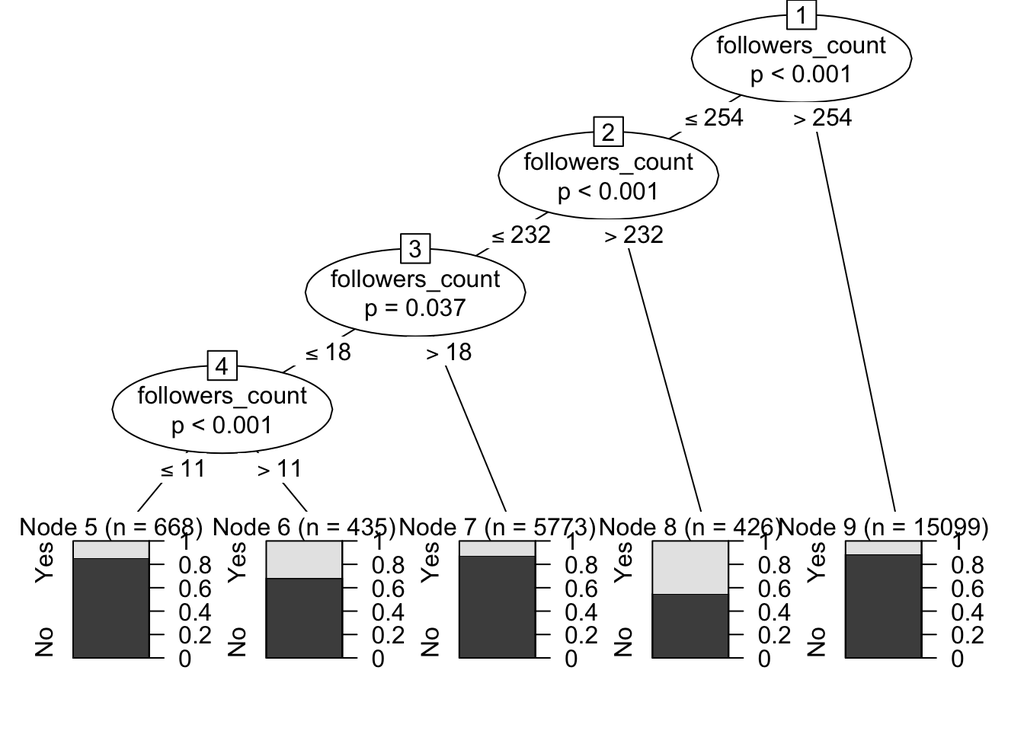

```r
plot(Tree_Model)
```

#### Cart

##### Running Model

```r
# data preparation
SPY_CART$Bullish <- ifelse(str_detect(SPY_CART$text, regex('bullish|bull Market|long|call|BTFD|Bottom', ignore_case = TRUE)), "Yes", "No")

SPY_CART$Bullish <- factor(SPY_CART$Bullish, levels = c("Yes","No"))


# sample data
# Set the random seed for repeatability
set.seed(321)

# Split the data into 3:1 ratio
sample_CART = sample.split(SPY_CART$Bullish, SplitRatio = .75)
train_CART = subset(SPY_CART, sample_CART == TRUE)
test_CART  = subset(SPY_CART, sample_CART == FALSE)

# build cart tree
cart_Model <- rpart(Bullish ~ followers_count + favorite_count + retweet_count, data = train_CART)

# prediction
pred.cart <- predict(cart_Model, newdata = test_CART, type = "class")
table(test_CART$Bullish, pred.cart, dnn = c("Actual", "Prediction"))
```

```
##       Prediction
## Actual  Yes   No
##    Yes    0  854
##    No     0 6613
```

```r
# Generate a confusion matrix
Accuracy_CART <- confusionMatrix(test_CART$Bullish, pred.cart)
```

```
## Accuracy: 0.8856301
```

##### Visualization

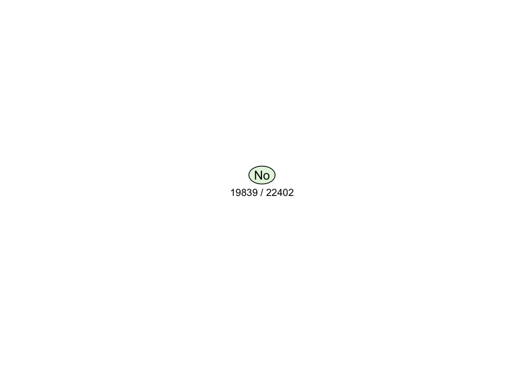

```r
rpart.plot(cart_Model, extra = 2, under = TRUE)
```

#### Conclusion

In our C-Tree model we can identify than the most important independent variable is followers count while verified is being excluded. Therefore, in our tweets data having a Verified account is not relevant to indicate if they are Bearish or not. On the other hand, in our CART tree model, the plot seems not to plot our variables meaning that our model might be overfitted.

### 7. Naive Base Model

We worked with a Naive Base Model to be able to classify whether our future tweets will include tickers about the S & P 500 ($SPY, $SPX ). We factored a new columns with levels “Yes” and “No” to indicate the inclusions of the tickers. We ran the model with the independent variables ‘followers_count’, ‘favorite_count’ and ‘retweet_count’

#### Running Model

```r
# data preparation
SPY_NB$contains.SPX <- ifelse(str_detect(SPY_NB$text, regex('SPX| $SPX', ignore_case = TRUE)), "Yes", "No")

SPY_NB$contains.SPX <- as.factor(SPY_NB$contains.SPX)

# sample the data
# Set the random seed for repeatability
set.seed(123)

# Split the data into 3:1 ratio
sample_NB = sample.split(SPY_NB$contains.SPX, SplitRatio = .75)
train_NB = subset(SPY_NB, sample_NB == TRUE)
test_NB = subset(SPY_NB, sample_NB == FALSE)

# build the naive bayes classifier
SPY_NBmodel <- naiveBayes(contains.SPX ~ followers_count + favorite_count + retweet_count, data = train_NB)

# predict the class
# Perform on the testing set
NB_prediction <- predict(SPY_NBmodel, test_NB, type = "class")

# Confusion Matrix
table(test_NB$contains.SPX, NB_prediction, dnn = c("Actual", "Prediction"))
```

```
##       Prediction
## Actual   No  Yes
##    No  5642   69
##    Yes 1718   38
```

```r
# Output results
data.frame(test_NB, Prediction = NB_prediction)
```

```r
#accuracy
Accuracy_NB <- confusionMatrix(test_NB$contains.SPX, NB_prediction)

# Calculate Precision
precision_NB <- precision(test_NB$contains.SPX, NB_prediction)

# Calculate Recall
recall_NB <- recall(test_NB$contains.SPX, NB_prediction)
```

```
## Accuracy: 0.7606803
```

```
## Precision: 0.9879181
```

```
## Recall: 0.7665761
```

#### Conclusion

In our Naive Model we obtained strong results doing our verification process. With our accuracy being 76%, precision 98%, and recall 76%. Therefore, moving forward we will be able to use the same variables with new data and be able to effectively classify if our tweets involved $SPX and $SPY

### 8. Clustering

As we were thinking of the best data set to utilize for our Clustering model, we decided to work with our ‘KeyWordsSentiment’ which reflected specific financial terms both formal and informal that are typically used by traders and/or people involved in Twitter for financial market purposes as sentiment.

#### Running Model

```r
# data preparation
# we will use the KeyWordsSentiment2 data set we created for our text sentiment analysis

KeyWordsSentiment2 <- mutate(KeyWordsSentiment2, Sentiment = ifelse(Sentiment == "Positive", "1", "0"))

KeyWordsSentiment2$Sentiment <- as.integer(KeyWordsSentiment2$Sentiment)

# sample the data
# Set the random seed
set.seed(20)

# Extract only Sentiment and Count data for clustering
Sentiment <- data.frame(Count = KeyWordsSentiment2$Count, Sentiment = KeyWordsSentiment2$Sentiment)
head(Sentiment)
```

```
##   Count Sentiment
## 1   673         1
## 2   282         0
## 3    40         1
## 4    15         0
## 5  1197         1
## 6  1193         0
```

```r
# within sum of squares
# For each k, perform WSS, store the value
wssSentiment <- numeric(6)
for (k in 1:6){
  wssSentiment[k] = sum(kmeans(Sentiment, k, nstart = 25)$withinss)
}

# Make a data out of the WSS results
wssSentimentResults <- data.frame(k = c(1:6), WSS = wssSentiment)
wssSentimentResults
```

```
##   k         WSS
## 1 1 4000017.917
## 2 2  455985.543
## 3 3  175724.733
## 4 4   84457.900
## 5 5    3441.833
## 6 6    1816.833
```

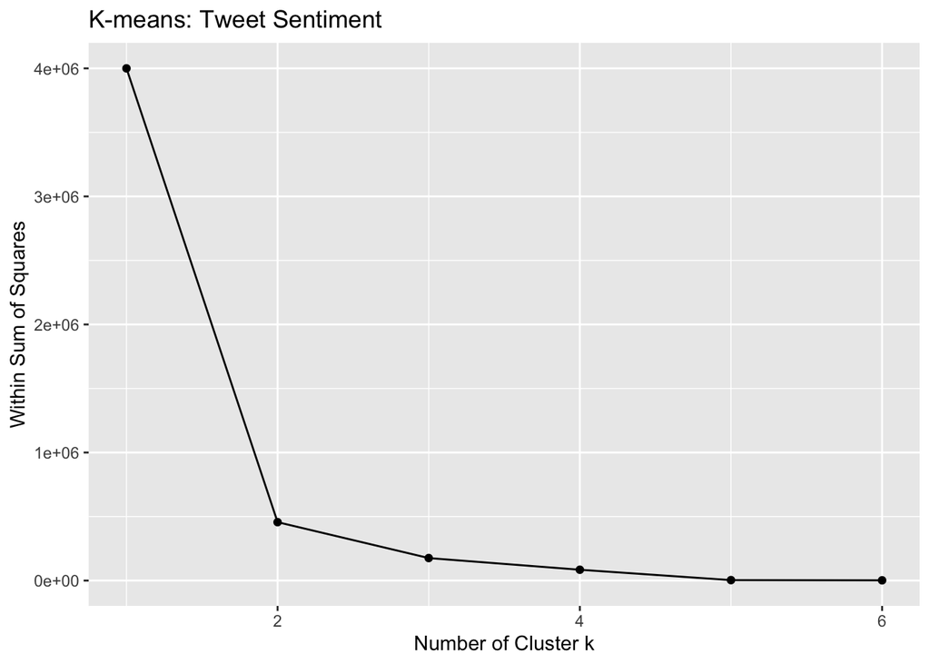

```r
# visualize WSS and determine k
ggplot(data = wssSentimentResults, mapping = aes(x = k, y = WSS)) +
  geom_point() +
  geom_line() +
  labs(title = "K-means: Tweet Sentiment",
       x = "Number of Cluster k",
       y = "Within Sum of Squares")
```

```r
# perform kmeans with k set to 2
SentimentCluster <- kmeans(Sentiment, 2, nstart = 25)

# verification
table(SentimentCluster$cluster, KeyWordsSentiment2$Sentiment)
```

```
##
##     0 1
##   1 3 4
##   2 3 2
```

#### Visualizations

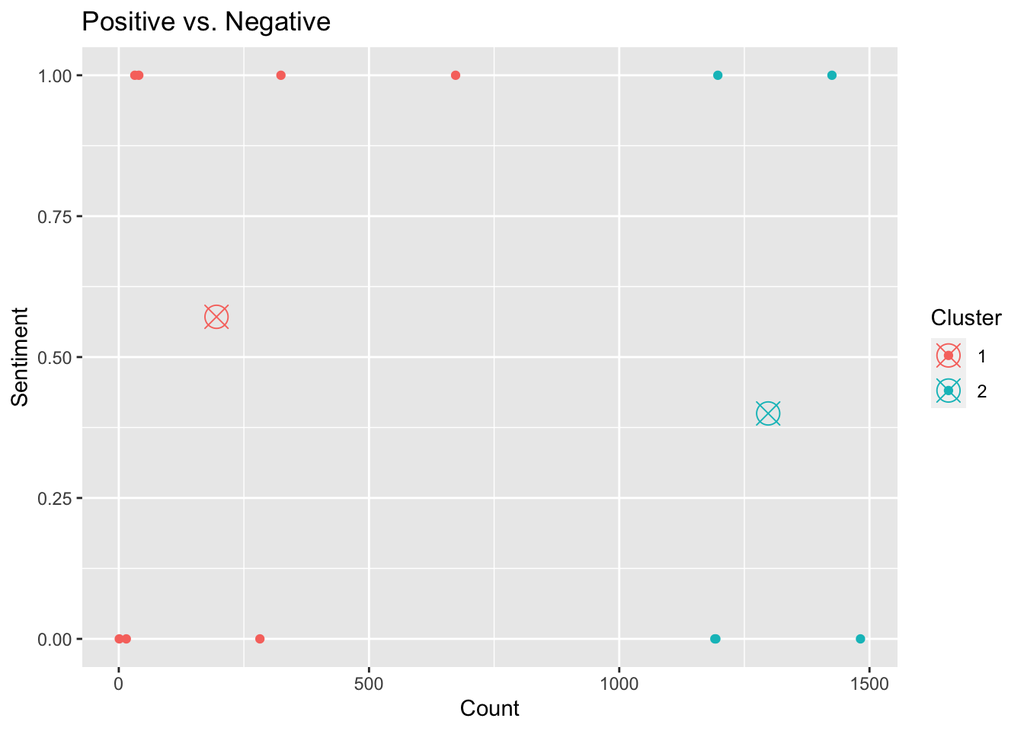

```r
# add the cluster assignment to each point
KeyWordsSentiment2$Cluster <- as.factor(SentimentCluster$cluster)

# Get centroids
centroidsSentiment <- as.data.frame(SentimentCluster$centers)
centroidsSentiment$Cluster <- as.factor(c(1:2))


# Visualize cluster assignment
ggplot(data = KeyWordsSentiment2, mapping = aes(Count, Sentiment, color = Cluster)) +
  geom_point() +
  geom_point(data = centroidsSentiment, aes(x = Count, y = Sentiment, fill = Cluster), size = 5, shape = 13) +
  labs(title = "Positive vs. Negative",
       x = "Count",
       y = "Sentiment")
```

#### Conclusion

We realized, when creating our Clustering model, that our data was not fittted for this type of model, and we couldn’t reach any valuable decision using this model.

### 9. Time Series

In our Time Series analysis, we wanted to forecast if our tweets in the future will be Organic or No Organic. We decided to work with ‘Twitter for iPhone’ trying to capture younger users. Additionally, working with when the tweets were created, we preformed and split the default format ( Y - M - D : H - M - S) into new variables called Date (Y - M - D) and Time (H - M - S).

#### Running Model

```r
# data preparation
SPY_TS <- mutate(SPY_TS, Organic = ifelse(source == "Twitter Web App" | source == "Twitter for iPhone" | source == "Twitter for Android", "Organic", "No Organic"))

SPY_TS. <- SPY_TS %>%
  filter(source == "Twitter for iPhone") %>%
  select(source, Date, Time, Organic) %>%
  arrange(Date, Time)


SPY_TS.$Time <- hour(as.hms(SPY_TS.$Time))
SPY_TS.$Date <- as.numeric(as.Date(SPY_TS.$Date))

SPY_TS. <- SPY_TS. %>%
  arrange(Date, Time) %>%
  group_by(Date, Time) %>%
  summarize(count= n())
# decompose
TS_SPY <-  ts(SPY_TS.$count, start = c(18586, 14), end = c(18601, 21), frequency = 24)

# Build the ARIMA model
arimaSPY <- auto.arima(TS_SPY)
arimaSPY
```

```
## Series: TS_SPY
## ARIMA(2,0,2)(1,0,0)[24] with non-zero mean
##
## Coefficients:
##           ar1     ar2     ma1      ma2    sar1     mean
##       -0.1354  0.7714  0.7670  -0.1969  0.3937  16.0064
## s.e.   0.0613  0.0506  0.0799   0.0690  0.0509   3.0386
##
## sigma^2 estimated as 75.39:  log likelihood=-1316.87
## AIC=2647.74   AICc=2648.05   BIC=2675.1
```

```r
# predict 5 days into the future
ForecastSPY <- forecast(arimaSPY, h = 120)
```

#### Visualizations

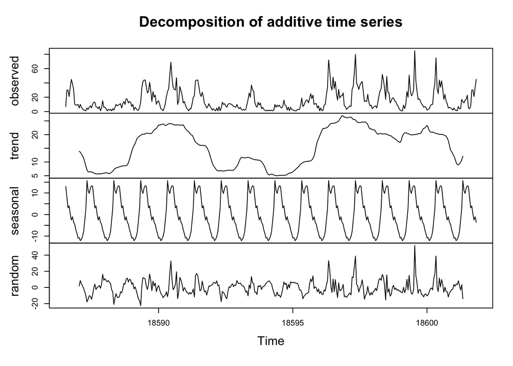

```r
# decompose plot
plot(decompose(TS_SPY))
```

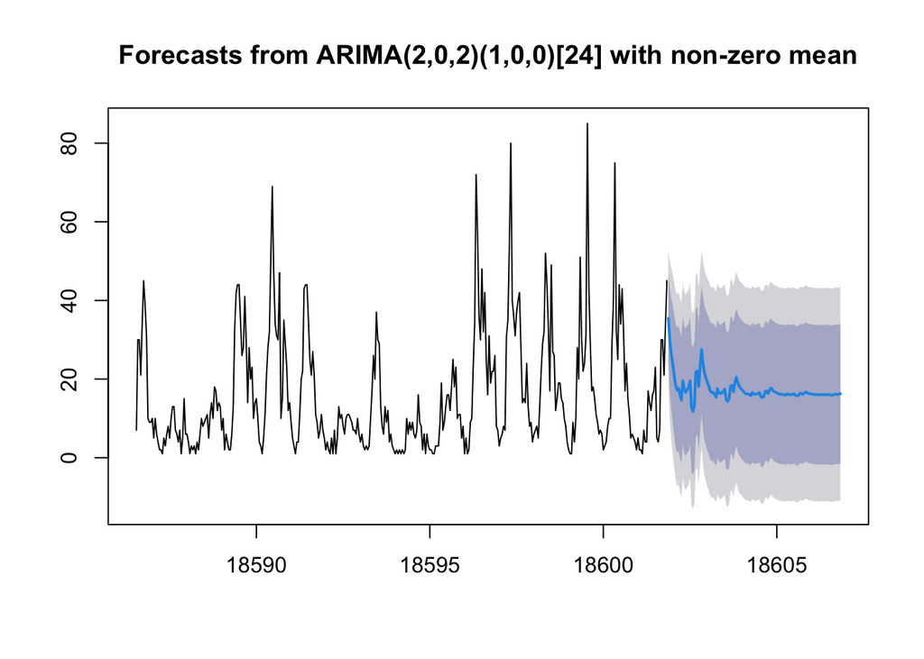

```r
# forecast plot
plot(ForecastSPY)
```

### 10.Project Conclusion

Through out our project, we analyzed the sentiment from a diversity of tweets collected randomly from Twitter, This sentiment came up to be Bullish Neutral, which states that users are cautiously optimistic in the Stock Market. Additionally, while performing several statistical analysis, we were able to predict certain characteristics of the tweets that would allow to perform the same experiment with new data, and be able to analyzed its sentiment.